# **Data Wrangling & EDA in R**

Nina Oryshkewych

# **Data Wrangling**

Data wrangling is the process of cleaning, reshaping, and preparing data for analysis. This is a critical step in the analytic process, as it ensures valid, accurate results and that your analyses are answering the questions you intend to ask.

## Tidyverse

```r
library(tidyverse)
```

Tidyverse is a collection of R packages designed for data wrangling and exploratory data analysis, with an emphasis on readable and consistent syntax. For many users, this approach makes code easier to read and write than base R. Most of this tutorial will show tidyverse-style code.

## Reading in Data

Often times, we receive data in various file formats, which requires different packages and functions. The options below are most commonly used for datasets we typically recieve in sleep/circadian research.

- **readr:** for .csv and .tsv files
- **readxl:** for .xls and .xlsx files
- **haven:** for SPSS (.sav), SAS (.sas7bdat), and Stata (.dta) files

### Examples

The code below can be used to make example datasets that will be used for demonstration purposes. Be sure to replace the data directory with your own. The dataset will include 30 participants with basic demographic information and repeated measurements of mood and sleep.

```r
library(readr)
library(readxl)
library(haven)
library(writexl)
datadir <- "X:\\SHARC\\Code\\Data Wrangling & EDA\\Data\\"
set.seed(123)

# Define IDs and timepoints
ids <- 1:30
timepoints <- c("T1", "T2", "T3")

# Person-level baseline dates
baseline_date <- as.Date("2024-01-01") +
  sample(0:30, length(ids), replace = TRUE)


# Person-level education
education_person <- sample(c("High school", "College", "Graduate degree"),
                           length(ids),
                           replace = TRUE,
                           prob = c(0.3, 0.4, 0.3))

example_data <- expand_grid(ID = ids,
                            timepoint = timepoints) %>%
  mutate(
    # mood, varies by time point
    mood = rnorm(n(), mean = 50, sd = 15),

    # sex
    sex = labelled(rep(sample(c(0, 1), length(ids), replace = TRUE), each = length(timepoints)),
                   labels = c(Male = 0, Female = 1),
                   label = "Participant sex"),

    # Education (person-level, repeated)
    education = rep(education_person, each = length(timepoints)),

    # POSIXct bedtime varies by time point

    bedtime = as.POSIXct(rep(baseline_date, each = length(timepoints)) +
                         case_when(timepoint == "T1" ~ 0,
                                   timepoint == "T2" ~ sample(30:90, n(), replace = TRUE),
                                   timepoint == "T3" ~ sample(120:180, n(), replace = TRUE))) +
                         hours(sample(21:24, n(), replace = TRUE)) +
                         minutes(sample(c(0, 15, 30, 45), n(), replace = TRUE)))



# save datasets
save(example_data, file = paste0(datadir, "\\example_data.RData"))
saveRDS(example_data, file = paste0(datadir, "\\example_data.rds"))
write_csv(example_data, file = paste0(datadir, "\\example_data.csv"))
write_xlsx(example_data, path = paste0(datadir, "\\example_data.xlsx"))
write_sav(example_data, path = paste0(datadir, "\\example_data.sav"))
write_dta(example_data, path = paste0(datadir, "\\example_data.dta"))
write_xpt(example_data, path = paste0(datadir, "\\example_data.xpt"))
```

Below, we read our data back in using import functions from the packages mentioned above.

```r
csv_data_raw <- read_csv(paste0(datadir, "\\example_data.csv"))
xlsx_data_raw <- read_excel(paste0(datadir, "\\example_data.xlsx"))
sav_data_raw <- read_sav(paste0(datadir, "\\example_data.sav"))
dta_data_raw <- read_dta(paste0(datadir, "\\example_data.dta"))
xpt_data_raw <- read_xpt(paste0(datadir, "\\example_data.xpt"))
```

**Best practice:** Save an untouched version of each dataset immediately after reading it in. Treat this object as read-only and perform all cleaning on copies. This makes it much easier to diagnose errors and retrace your steps later.

### Special haven Functionality

The haven package is particularly useful because it preserves metadata embedded in SPSS and SAS files, such as variable labels and value labels. This feature is especially helpful for categorical variables that are numerically coded (e.g., 0 = “No”, 1 = “Yes”), as it allows you to inspect coding of categorical variables without the need for a separate codebook.

To inspect the value labels of a variable, use attr()

```r
attr(sav_data_raw$sex, "labels")
```

```
##   Male Female
##      0      1
```

Important caveat - the metadata that haven preserves requires some variables to be stored as labelled vectors, rather than standard R vectors. This can sometimes (but not always) cause issues when merging with other datasets. To eliminate this problem, you can use zap_labels() on your haven dataset to convert labelled variables to standard R vectors.

```r
sav_data_nolabels <- zap_labels(sav_data_raw)
```

We can check that this worked properly by using attr() again

```r
attr(sav_data_nolabels$sex, "labels")
```

[output not shown]

### R Objects and Datasets

Occasionally, data are stored as R-specific objects, which are not limited to dataframes. These often come in two forms:

- **.RData:** loaded using load(), which can introduce multiple objects into your environment
- **.rds:** read using readRDS(), which returns a single object

```r
load("X:\\SHARC\\Code\\Data Wrangling & EDA\\Data\\example_data.RData")
rds_data <- readRDS("X:\\SHARC\\Code\\Data Wrangling & EDA\\Data\\example_data.rds")
```

An important distinguishing factor between these two functions is that with load() reads objects directly into the R environment without assignment (using their original object names), whereas readRDS() imports a single object that must be assigned to a name, similar to other import functions.

## Data Types in R

The following are common data types in R:  
* numeric  
* character  
* factor  
* POSIXct (dates/times)

```r
head(sav_data_raw)
```

```
## # A tibble: 6 × 6
##      ID timepoint  mood sex        education       bedtime
##   <dbl> <chr>     <dbl> <dbl+lbl>  <chr>           <dttm>
## 1     1 T1         30.3 1 [Female] High school     2024-01-31 21:45:00
## 2     1 T2         41.0 1 [Female] High school     2024-04-21 00:30:00
## 3     1 T3         48.1 1 [Female] High school     2024-06-01 00:15:00
## 4     2 T1         63.3 0 [Male]   Graduate degree 2024-01-15 23:30:00
## 5     2 T2         47.7 0 [Male]   Graduate degree 2024-04-07 22:45:00
## 6     2 T3         54.9 0 [Male]   Graduate degree 2024-07-01 21:45:00
```

### Working with Factor Variables

forcats (part of tidyverse) is a handy package for working with factor variables. Common usage includes releveling and collapsing factor variables. Additional forcats usage can be found [here](https://rstudio.github.io/cheatsheets/factors.pdf).

Below, we change the reference group in sex using fct_relevel() and collapse education into two categories using fct_collapse().

```r
sav_data <- sav_data_raw %>%
  mutate(sex = factor(sex, levels = 0:1, labels = c("Male", "Female")),
         sex_m = fct_relevel(sex, "Female"),
         education = factor(education, levels = c("High school", "College", "Graduate degree")),
         education_collapsed = fct_collapse(education,
                                            "High school" = "High school",
                                            "College+" = c("College", "Graduate degree")))
```

Original sex variable:

```r
levels(sav_data$sex)
```

```
## [1] "Male"   "Female"
```

```r
levels(sav_data$sex_m)
```

```
## [1] "Female" "Male"
```

Original education variable:

```r
levels(sav_data$education)
```

```
## [1] "High school"     "College"         "Graduate degree"
```

Education collapsed to two categories:

```r
levels(sav_data$education_collapsed)
```

```
## [1] "High school" "College+"
```

### Working with Character Variables

The stringr package (part of tidyverse) is used to manipulate character variables. Common use cases include concatenating strings and extracting substrings. Additional stringr usage can be found [here](https://rstudio.github.io/cheatsheets/strings.pdf).

Below, we extract the timepoint number from the variable timepoint using str_extract() and use this to create a new timepoint variable, using str_c()

```r
sav_data <- sav_data %>%
  mutate(timepoint_num = str_extract(timepoint, "1|2|3"),
         timepoint_new = str_c("Timepoint ", timepoint_num))
```

Inspect new variables:

```r
sav_data %>%
  select(timepoint, timepoint_num, timepoint_new) %>%
  head()
```

```
## # A tibble: 6 × 3
##   timepoint timepoint_num timepoint_new
##   <chr>     <chr>         <chr>
## 1 T1        1             Timepoint 1
## 2 T2        2             Timepoint 2
## 3 T3        3             Timepoint 3
## 4 T1        1             Timepoint 1
## 5 T2        2             Timepoint 2
## 6 T3        3             Timepoint 3
```

### Working with Dates and Times

lubridate is a tidyverse package that is excellent for working with dates and times. Common use cases include: extracting time components and computing day of week. Additional lubridate usage can be found [here](https://rstudio.github.io/cheatsheets/lubridate.pdf).

Oftentimes in sleep research, we need to times from clock format to decimal format. An example is shown below. Additionally, we create a day of week variable using wday().

```r
convert_times <- function(time) {
  time <- as.POSIXct(time, format = "%H:%M:%OS")
  hours <- as.numeric(hour(time))
  min <- as.numeric(minute(time))
  dec_time <- hours + min/60

  return(dec_time)
}

sav_data <- sav_data %>%
  mutate(bedtime_dec = convert_times(bedtime),
         day_of_week = wday(bedtime, label = T))
```

Inspect new variables:

```r
sav_data %>%
  select(ID, timepoint, bedtime, bedtime_dec, day_of_week) %>%
  head()
```

```
## # A tibble: 6 × 5
##      ID timepoint bedtime             bedtime_dec day_of_week
##   <dbl> <chr>     <dttm>                    <dbl> <ord>
## 1     1 T1        2024-01-31 21:45:00       21.8  Wed
## 2     1 T2        2024-04-21 00:30:00        0.5  Sun
## 3     1 T3        2024-06-01 00:15:00        0.25 Sat
## 4     2 T1        2024-01-15 23:30:00       23.5  Mon
## 5     2 T2        2024-04-07 22:45:00       22.8  Sun
## 6     2 T3        2024-07-01 21:45:00       21.8  Mon
```

**Best practice:** When creating derived variables (e.g., decimal time, dichotomized categorical variable), use a consistent naming convention such as suffixes (*dec, *bin) or prefixes (dec*, bin*). This makes datasets easier to scan and reduces the potential for errors when selecting variables programmatically.

## Merging Datasets

Once individual datasets are read in and cleaned, they are ready to be combined into a single analytic dataset. The *_join() family of functions from dplyr provides a clear way to merge datasets using key variables (e.g., participant ID).

- **full_join():** keeps all rows from both datasets
- **left_join():** keeps all rows from the first dataset
- **right_join():** keeps all rows from the second dataset
- **inner_join():** keeps only rows with matching keys

**Best practice:** To reduce the risk of unintentionally dropping observations that should be retained, begin with a full_join() and explicitly filter unwanted rows afterward. Left, right, and inner joins should only be used when you are confident in the structure of your data and are certain that excluding non‑matching rows is appropriate.

## Reshaping Data

Below, we reshape our dataframe from long to wide format, using pivot_wider().

```r
# removing time point variables created in prior example so they do not interfere with reshaping
sav_data <- sav_data %>%
  select(-timepoint_num, -timepoint_new)
```

```r
sav_data_wide <- sav_data %>%
  pivot_wider(names_from = timepoint, # timepoint is used to name the new variables
              values_from = c(mood, bedtime, bedtime_dec, day_of_week)) # repeatedly measured values we are pivoting to wide format
```

Inspect new dataframe:

```r
sav_data_wide %>%
  select(ID, ends_with(c("T1", "T2", "T3"))) %>%
  head()
```

```
## # A tibble: 6 × 13
##      ID mood_T1 bedtime_T1          bedtime_dec_T1 day_of_week_T1 mood_T2
##   <dbl>   <dbl> <dttm>                       <dbl> <ord>            <dbl>
## 1     1   30.3  2024-01-31 21:45:00           21.8 Wed               41.0
## 2     2   63.3  2024-01-15 23:30:00           23.5 Mon               47.7
## 3     3    1.59 2024-01-19 23:45:00           23.8 Fri               38.4
## 4     4   31.7  2024-01-14 23:45:00           23.8 Sun               56.5
## 5     5   47.5  2024-01-03 23:30:00           23.5 Wed               68.6
## 6     6   55.9  2024-01-10 22:30:00           22.5 Wed               56.1
## # ℹ 7 more variables: bedtime_T2 <dttm>, bedtime_dec_T2 <dbl>,
## #   day_of_week_T2 <ord>, mood_T3 <dbl>, bedtime_T3 <dttm>,
## #   bedtime_dec_T3 <dbl>, day_of_week_T3 <ord>
```

We can reshape our wide dataframe back to long format using pivot_longer()

```r
sav_data_long <- sav_data_wide %>%
  pivot_longer(cols = ends_with(c("T1", "T2", "T3")), # selects wide repeated measures
               names_to = c(".value", "timepoint"), # create multiple columns that map to timepoint
               names_pattern = "(.*)_(T[123])") # split column names at the underscore
```

Inspect new dataframe:

```r
sav_data_long %>%
  select(ID, timepoint, mood, bedtime, bedtime_dec, day_of_week) %>%
  head()
```

```
## # A tibble: 6 × 6
##      ID timepoint  mood bedtime             bedtime_dec day_of_week
##   <dbl> <chr>     <dbl> <dttm>                    <dbl> <ord>
## 1     1 T1         30.3 2024-01-31 21:45:00       21.8  Wed
## 2     1 T2         41.0 2024-04-21 00:30:00        0.5  Sun
## 3     1 T3         48.1 2024-06-01 00:15:00        0.25 Sat
## 4     2 T1         63.3 2024-01-15 23:30:00       23.5  Mon
## 5     2 T2         47.7 2024-04-07 22:45:00       22.8  Sun
## 6     2 T3         54.9 2024-07-01 21:45:00       21.8  Mon
```

**Best practice:** data should almost always be in long format for R analyses. Long format works best for plotting, summary tables, and mixed effect analyses.

## More dplyr functions

- **select():** select columns
- **mutate():** create new columns or modify existing ones
- **filter():** subset data according to logical conditions
- **drop_na():** remove rows with missing values
- **rename():** rename variables
- **distinct():** remove duplicate rows
- **count():** create frequency tables

In the example below, we create a baseline dataset from our original longitudinal dataset.

```r
sav_data_baseline <- sav_data %>%
  filter(timepoint == "T1") %>% # extract first timepoint
  select(ID, sex, education, education_collapsed) %>% # select baseline variables
  distinct() %>% # remove duplicates (each participant originally had 3 rows)
  drop_na(education) %>% # drop participants with missing education
  rename(college_education = education_collapsed) # rename new education variable
```

Inspect new dataset:

```r
head(sav_data_baseline)
```

```
## # A tibble: 6 × 4
##      ID sex    education       college_education
##   <dbl> <fct>  <fct>           <fct>
## 1     1 Female High school     High school
## 2     2 Male   Graduate degree College+
## 3     3 Female High school     High school
## 4     4 Male   College         College+
## 5     5 Male   Graduate degree College+
## 6     6 Male   High school     High school
```

Check frequency of each ID (baseline dataset should include each ID once):

```r
sav_data_baseline %>% count(ID, sort = T)
```

```
## # A tibble: 30 × 2
##       ID     n
##    <dbl> <int>
##  1     1     1
##  2     2     1
##  3     3     1
##  4     4     1
##  5     5     1
##  6     6     1
##  7     7     1
##  8     8     1
##  9     9     1
## 10    10     1
## # ℹ 20 more rows
```

Check frequency of each ID in longitudinal dataset (should include each ID 3 times):

```r
sav_data %>% count(ID, sort = T)
```

```
## # A tibble: 30 × 2
##       ID     n
##    <dbl> <int>
##  1     1     3
##  2     2     3
##  3     3     3
##  4     4     3
##  5     5     3
##  6     6     3
##  7     7     3
##  8     8     3
##  9     9     3
## 10    10     3
## # ℹ 20 more rows
```

Check frequency of each ID and time point in longitudinal dataset (each ID/time point pair should occur once):

```r
sav_data %>% count(ID, timepoint)
```

```
## # A tibble: 90 × 3
##       ID timepoint     n
##    <dbl> <chr>     <int>
##  1     1 T1            1
##  2     1 T2            1
##  3     1 T3            1
##  4     2 T1            1
##  5     2 T2            1
##  6     2 T3            1
##  7     3 T1            1
##  8     3 T2            1
##  9     3 T3            1
## 10     4 T1            1
## # ℹ 80 more rows
```

# **Exploratory Data Analysis (EDA)**

Exploratory data analysis is the next step in the data analytic workflow after data wrangling. EDA is used to do the following:

- check distributions of key variables
- check for missingness
- check for outliers
- check modeling assumptions

EDA and data wrangling are often become an iterative process, as EDA will inform you of errors or additional modifications that need to be done to the data before further analyses can be performed.

## Summary Tables

A quick way to check your dataset is by using the summary() function

```r
summary(sav_data)
```

```
##        ID        timepoint              mood           sex
##  Min.   : 1.0   Length:90          Min.   : 1.59   Male  :51
##  1st Qu.: 8.0   Class :character   1st Qu.:40.59   Female:39
##  Median :15.5   Mode  :character   Median :49.02
##  Mean   :15.5                      Mean   :50.06
##  3rd Qu.:23.0                      3rd Qu.:57.40
##  Max.   :30.0                      Max.   :82.25
##
##            education     bedtime                       sex_m
##  High school    :21   Min.   :2024-01-03 23:30:00   Female:39
##  College        :45   1st Qu.:2024-01-26 05:52:30   Male  :51
##  Graduate degree:24   Median :2024-03-12 22:00:00
##                       Mean   :2024-03-26 17:41:50
##                       3rd Qu.:2024-05-30 11:26:15
##                       Max.   :2024-07-08 23:45:00
##
##   education_collapsed  bedtime_dec    day_of_week
##  High school:21       Min.   : 0.00   Sun: 9
##  College+   :69       1st Qu.: 0.75   Mon:15
##                       Median :21.88   Tue:13
##                       Mean   :16.10   Wed:12
##                       3rd Qu.:22.75   Thu:14
##                       Max.   :23.75   Fri:11
##                                       Sat:16
```

Use group_by() paired with summarize() to compute summary statistics by grouping variables

```r
sav_data_raw %>%
  group_by(timepoint) %>%
  summarize(mean_mood = mean(mood))
```

```
## # A tibble: 3 × 2
##   timepoint mean_mood
##   <chr>         <dbl>
## 1 T1             46.1
## 2 T2             51.7
## 3 T3             52.4
```

```r
sav_data_raw %>%
  group_by(timepoint, sex) %>%
  summarize(mean_mood = mean(mood))
```

```
## # A tibble: 6 × 3
## # Groups:   timepoint [3]
##   timepoint sex        mean_mood
##   <chr>     <dbl+lbl>      <dbl>
## 1 T1        0 [Male]        50.0
## 2 T1        1 [Female]      40.9
## 3 T2        0 [Male]        51.1
## 4 T2        1 [Female]      52.5
## 5 T3        0 [Male]        50.2
## 6 T3        1 [Female]      55.2
```

## Visualizations

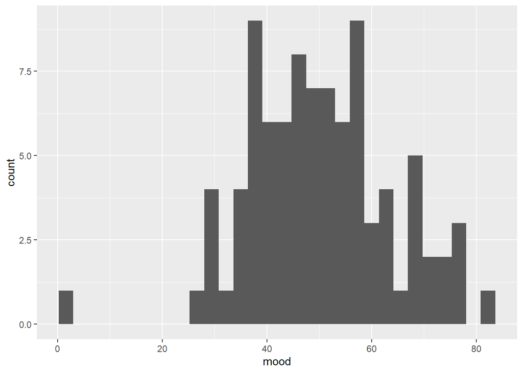

```r
ggplot(sav_data_raw, aes(x = mood)) +
  geom_histogram()
```

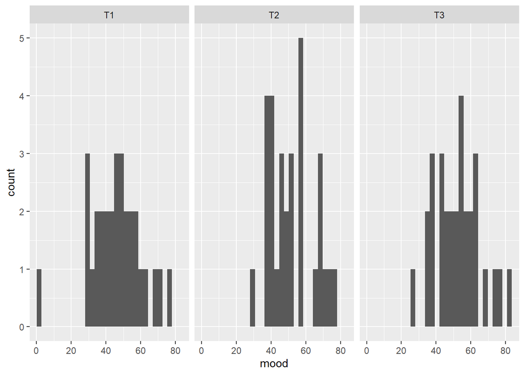

```r
ggplot(sav_data_raw, aes(x = mood)) +
  geom_histogram() +
  facet_wrap(~timepoint)
```

# **Tips for Checking the Final Analytic Dataset**

- Use count() to check for duplicate observations
- Save copies of the analytic dataset and after filtering. Check that the quantity of observations being dropped with each filter is consistent with expectations.
- Create tables of timepoints or days in repeated measures data
- Check for coded missingness vs true NAs
- Check that NAs are not a result of a “no” from a preceding question (WASO)
- Check for placeholder IDs